# TASK1

DS TASK1 #PRODIGY INFOTECH

Task1:Create histogram or bar chart to visualize distribution of continuous or categorical varaiables.

Dataset from KAGGLE Dataset Description:The Consumer Behavior and Shopping Habits Dataset provides comprehensive insights into consumers' preferences, tendencies, and patterns during their shopping experiences. This dataset encompasses a diverse range of variables, including demographic information, purchase history, product preferences, shopping frequency, and online/offline shopping behavior.

```python
import numpy as np #used for numerical operations
import pandas as pd #used for working with datasets for cleaning,exploring,manipulating
import matplotlib.pyplot as plt #for visualizing data using plots,charts
import seaborn as sns #for visualizing data using plots,charts
```

```python
#importing the dataset
df=pd.read_csv('C:/Users/SHINY/Documents/shopping_behavior_updated.csv')
```

```python
df.head()
```

|  | Customer ID | Age | Gender | Item Purchased | Category | Purchase Amount (USD) | Location | Size | Color | Season | Review Rating | Subscription Status | Shipping Type | Discount Applied | Promo Code Used | Previous Purchases | Payment Method | Frequency of Purchases |
| --- | --- | --- | --- | --- | --- | --- | --- | --- | --- | --- | --- | --- | --- | --- | --- | --- | --- | --- |
| 0 | 1 | 55 | Male | Blouse | Clothing | 53 | Kentucky | L | Gray | Winter | 3.1 | Yes | Express | Yes | Yes | 14 | Venmo | Fortnightly |
| 1 | 2 | 19 | Male | Sweater | Clothing | 64 | Maine | L | Maroon | Winter | 3.1 | Yes | Express | Yes | Yes | 2 | Cash | Fortnightly |
| 2 | 3 | 50 | Male | Jeans | Clothing | 73 | Massachusetts | S | Maroon | Spring | 3.1 | Yes | Free Shipping | Yes | Yes | 23 | Credit Card | Weekly |
| 3 | 4 | 21 | Male | Sandals | Footwear | 90 | Rhode Island | M | Maroon | Spring | 3.5 | Yes | Next Day Air | Yes | Yes | 49 | PayPal | Weekly |
| 4 | 5 | 45 | Male | Blouse | Clothing | 49 | Oregon | M | Turquoise | Spring | 2.7 | Yes | Free Shipping | Yes | Yes | 31 | PayPal | Annually |

```python
#checking for null values in our dataset
df.isnull().sum()
```

```
Customer ID               0
Age                       0
Gender                    0
Item Purchased            0
Category                  0
Purchase Amount (USD)     0
Location                  0
Size                      0
Color                     0
Season                    0
Review Rating             0
Subscription Status       0
Shipping Type             0
Discount Applied          0
Promo Code Used           0
Previous Purchases        0
Payment Method            0
Frequency of Purchases    0
dtype: int64
```

We can observe our dataset is clean so we can proceed with analysing our data

Let's check the data types of our data

```python
df.info()
```

```
<class 'pandas.core.frame.DataFrame'>
RangeIndex: 3900 entries, 0 to 3899
Data columns (total 18 columns):
 #   Column                  Non-Null Count  Dtype
---  ------                  --------------  -----
 0   Customer ID             3900 non-null   int64
 1   Age                     3900 non-null   int64
 2   Gender                  3900 non-null   object
 3   Item Purchased          3900 non-null   object
 4   Category                3900 non-null   object
 5   Purchase Amount (USD)   3900 non-null   int64
 6   Location                3900 non-null   object
 7   Size                    3900 non-null   object
 8   Color                   3900 non-null   object
 9   Season                  3900 non-null   object
 10  Review Rating           3900 non-null   float64
 11  Subscription Status     3900 non-null   object
 12  Shipping Type           3900 non-null   object
 13  Discount Applied        3900 non-null   object
 14  Promo Code Used         3900 non-null   object
 15  Previous Purchases      3900 non-null   int64
 16  Payment Method          3900 non-null   object
 17  Frequency of Purchases  3900 non-null   object
dtypes: float64(1), int64(4), object(13)
memory usage: 548.6+ KB
```

Now we can visualize which Gender has purchased more.For this pie chart would look better

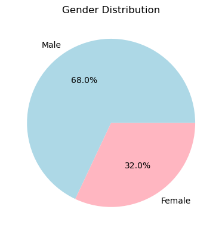

```python
#first checking for the count of Gender
gender_counts = df['Gender'].value_counts()

# Plotting Gender in pie chart
plt.figure(figsize=(10, 5))
plt.pie(gender_counts, labels=gender_counts.index, autopct='%1.1f%%', colors=['lightblue', 'lightpink'])
plt.title('Gender Distribution')
plt.show()
```

From the chart we can understand that our Shopping dataset has more male customers than female

Let's check which category is selling the most and least

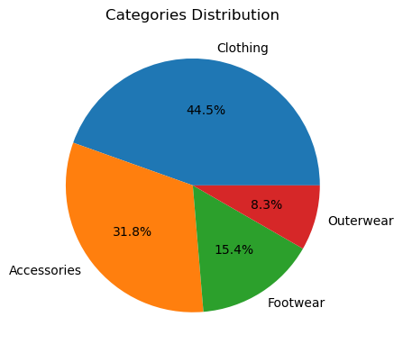

```python
category_counts = df['Category'].value_counts()

# Plotting categories in pie chart
plt.figure(figsize=(10, 5))
plt.pie(category_counts, labels=category_counts.index,autopct='%1.1f%%')
plt.title('Categories Distribution')
plt.show()
```

Now we can look into seasonal purchases

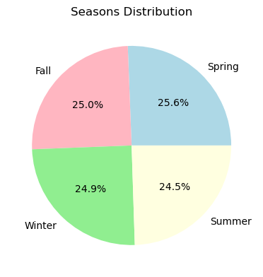

```python
season_counts = df['Season'].value_counts()

# Plotting categories in pie chart
plt.figure(figsize=(10, 5))
plt.subplot(1, 2, 2)
plt.pie(season_counts, labels=season_counts.index,autopct='%1.1f%%',colors=['lightblue', 'lightpink','lightgreen','lightyellow'])
plt.title('Seasons Distribution')
plt.show()
```

From the pie chart it is clearly understood people prefer to purchase during all seasons but comparing to all kind of less during summer.

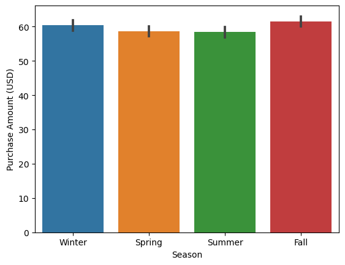

```python
import seaborn as sns
ax = sns.barplot(
                 x="Season",
                 y="Purchase Amount (USD)",
                 data=df)
```

From the bar plot it is evident during Winter and Fall people purchase more comparing others.

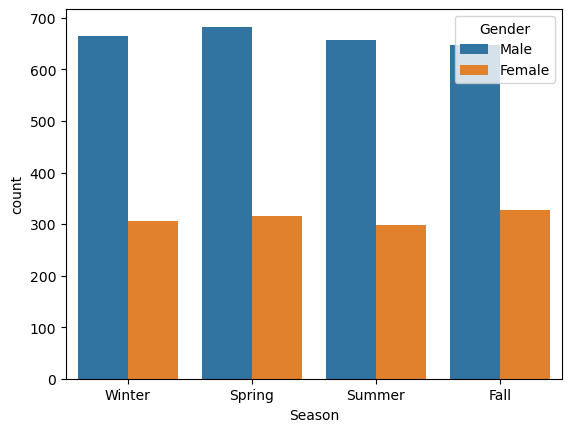

```python
ax = sns.countplot(
                   x="Season",
                   data=df,hue='Gender')
```

As we already know there are more male customers we can see that during spring male prefer to purchase more and females tend to purchase more during Fall.

We can visualize based on sizes

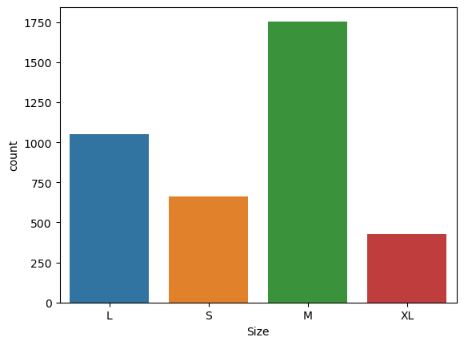

```python
ax = sns.countplot(
                   x="Size",
                   data=df)
```

We can see overall 'M' is the most purchased size and then comes 'L'.Less number of people prefer 'XL'

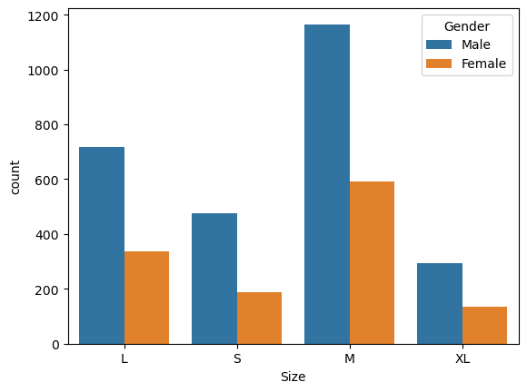

```python
ax = sns.countplot(
                   x="Size",
                   data=df,hue='Gender')
```

When we analyse deep sizes based on gender,even then both Male and Female prefer size 'M'

Analysis based on purchases

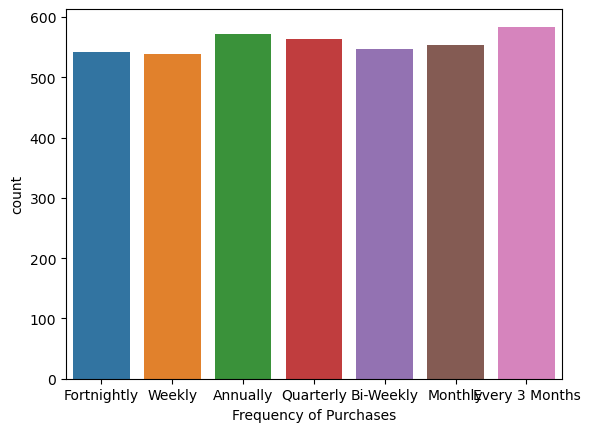

```python
ax = sns.countplot(
                   x="Frequency of Purchases",
                   data=df)
```

We can observe people purchase during all periods of time but every 3 months they tend to purchase also one category of people purchase annualy.

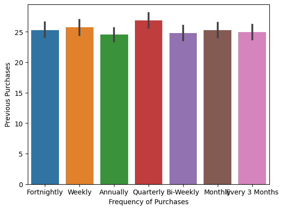

```python
ax = sns.barplot(
                 x="Frequency of Purchases",
                   y='Previous Purchases' ,
                 data=df)
```

Based on previous purchases consumer purchase more on quaterly basis and then weekly purchases are also little more.

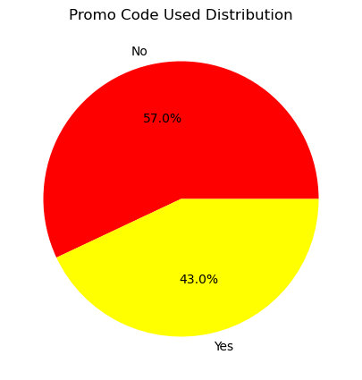

```python
code_counts = df['Promo Code Used'].value_counts()

# Plotting categories in pie chart
plt.figure(figsize=(10, 5))
plt.pie(code_counts, labels=code_counts.index,autopct='%1.1f%%',colors=['r','yellow'])
plt.title('Promo Code Used Distribution')
plt.show()
```

```python
We can see that many people purchase without promo code only
```

[output not shown]

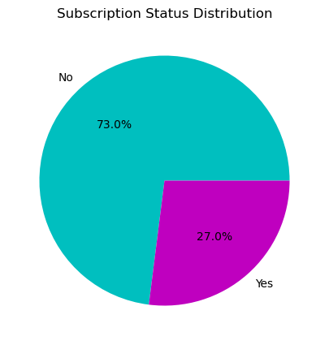

```python
status_counts = df['Subscription Status'].value_counts()

# Plotting categories in pie chart
plt.figure(figsize=(10, 5))
plt.pie(status_counts, labels=status_counts.index,autopct='%1.1f%%',colors=['c','m'])
plt.title('Subscription Status Distribution')
plt.show()
```

From the chart we can see Large amount of people purchase but do not have subscription only very few about quarter precent have subscription.

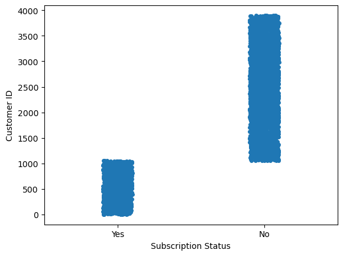

```python
ax = sns.stripplot(x='Subscription Status', y='Customer ID', data=df)
```